# Comparision of chosen UE countries in regards to health factors

Paweł Kopaniecki

# Prerequisites

```r
library(devtools)
#Uncomment and use them once to install dependencies
#devtools::install_github("Yard1/linearOrdering") #To install package with linearOrdering algorithm
#devtools::install_github("vqv/ggbiplot") #Run to install package with ggbiplot
```

# Load packages :

```r
require(readxl)
require(dplyr)
require(xlsx)
library(devtools)
require(ggbiplot)
require(linearOrdering)
require(caret)
require(cluster)
require(clusterSim)
require(ClusterR)
require(ggplot2)
require(reshape2)
require(gridExtra)
require(moments)
require(robustHD)
require(topsis)
require(xtable)
require(factoextra)
require(FactoMineR)
require(corrplot)
require(rworldmap)
require(maps)
require(RColorBrewer)
```

# Load data

```r
df <- read.xlsx2("Data.xlsx", sheetIndex = 1, row.names = 1)
df[] <- lapply(df, function(x) as.numeric(as.character(x)))
glimpse(df)
```

```
## Rows: 28
## Columns: 14
## $ hlty_total       <dbl> 63.4, 65.8, 62.7, 60.9, 65.8, 53.9, 69.4, 65.4, 68.0,…
## $ hlte_sph_total   <dbl> 75.6, 69.1, 72.7, 75.8, 75.2, 69.5, 79.7, 75.3, 77.9,…
## $ sph_total        <dbl> 28.4, 19.7, 19.9, 26.1, 18.0, 8.8, 45.7, 46.3, 22.6, …
## $ hbds_number      <dbl> 64248.0, 53173.0, 70351.0, 14077.0, 661880.0, 6046.0,…
## $ hlt_graduates    <dbl> 3282, 1102, 1700, 1335, 9563, 136, 1224, 1344, 6664, …
## $ hlt_per_exp_ncp  <dbl> 35762, 29625, 42919, 24301, 357401, 4605, 15962, 6550…
## $ acc_at_work      <dbl> 48409, 1794, 37530, 30991, 723704, 5216, 11764, 4098,…
## $ cds              <dbl> 8.4, 5.0, 4.2, 8.3, 9.4, 8.2, 4.9, 2.7, 4.8, 10.8, 8.…
## $ phy_number       <dbl> 13178, 4322, 6981, 4649, 82757, 1097, 8965, 4390, 357…
## $ cod              <dbl> 110604, 107292, 113127, 55053, 957564, 15650, 31140, …
## $ unm_needs        <dbl> 1.4, 1.5, 0.0, 0.2, 0.1, 0.5, 0.8, 8.0, 0.1, 0.7, 0.5…
## $ hlt_care_exp     <dbl> 47417.47, 4120.53, 15871.89, 30449.93, 383636.00, 173…
## $ lng_stnd_illness <dbl> 24.8, 23.3, 36.6, 29.6, 43.8, 48.4, 25.4, 23.4, 32.9,…
## $ splong_lim       <dbl> 16.5, 13.0, 20.2, 23.1, 15.1, 26.8, 10.9, 13.6, 16.2,…
```

# Map of analysed countries

```
## 28 codes from your data successfully matched countries in the map
## 0 codes from your data failed to match with a country code in the map
## 215 codes from the map weren't represented in your data
```

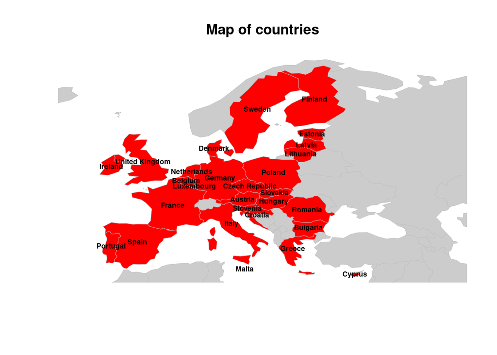

# Boxplot of raw data

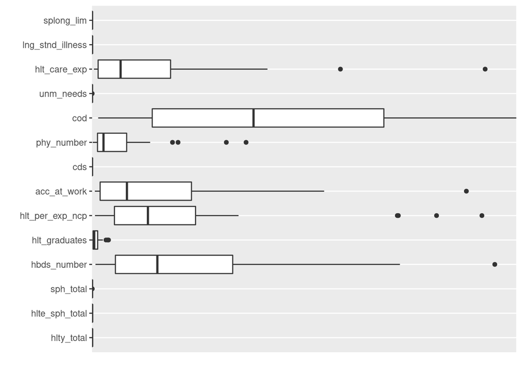

```r
ggplot(stack(df), aes(x = ind, y = values)) +
  coord_flip() +
  geom_boxplot() +
  scale_y_discrete() +
  ylab("") +
  xlab("") +
  theme(axis.text.x = element_text(angle = 45, hjust = 1))
```

# Histograms of density of raw data

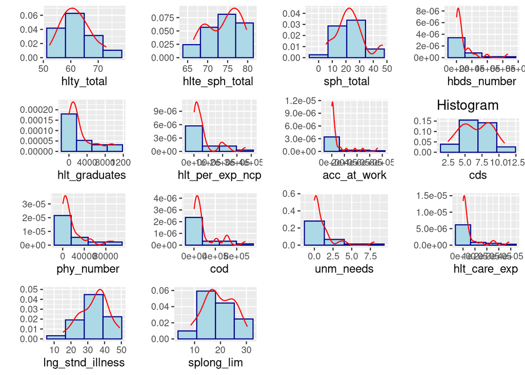

```r
do.call(grid.arrange, plist_p)
```

# Chosen variables compared with UE mean :

- hlty_total - mean is 63.6 (years) (2018)(EU 2013-2020)(28),
- sph_total - mean is 22.1 (percent) (2018) (EU 2013-2020)(28),
- lng_stnd_illness - mean is 36.8 (percent) (2018) (EU 2013-2020)(28),
- cds - mean is 6.7 (percent) (2014) (EU 2013-2020)(28).

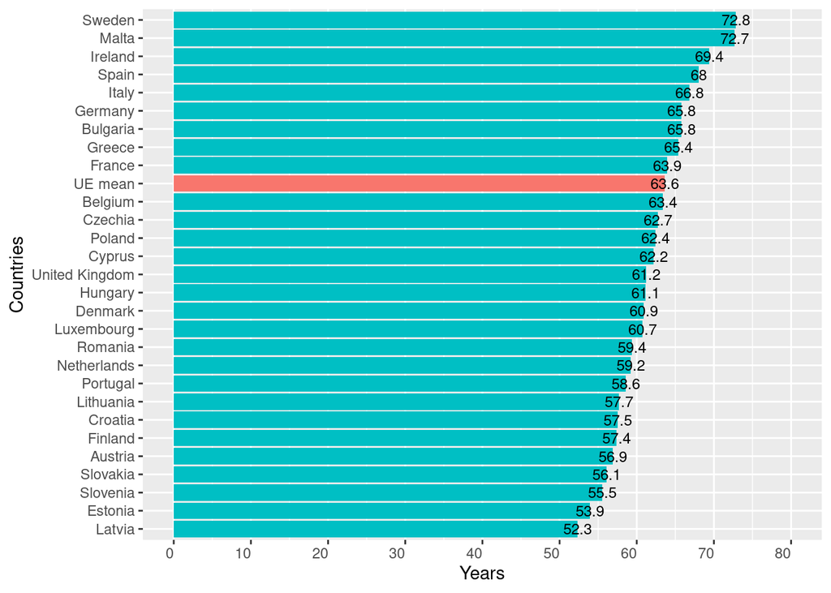

```r
df_mean <- df %>% add_row(hlty_total = 63.6, sph_total = 22.1, cds = 6.7, lng_stnd_illness = 36.8, .after = 28)
rownames(df_mean)[29] <- "UE mean"

#hlty_total
ggplot(data = df_mean, aes(x = reorder(rownames(df_mean), hlty_total), y = hlty_total,
                      fill = ifelse(rownames(df_mean) == "UE mean", "Highlighted", "Normal"))) +
  geom_bar(stat = "identity") +
  coord_flip() +
  xlab("Countries") +
  scale_y_continuous(breaks=seq(0, 80, by = 10), limits=c(0, 80)) +
  ylab("Years") +
  guides(fill = "none") +
  theme(axis.text.x = element_text(angle = 0, hjust = 1)) +
  geom_text(aes(label = hlty_total), size = 3.2, position = position_dodge(width = 0.9), vjust = 0.5)
```

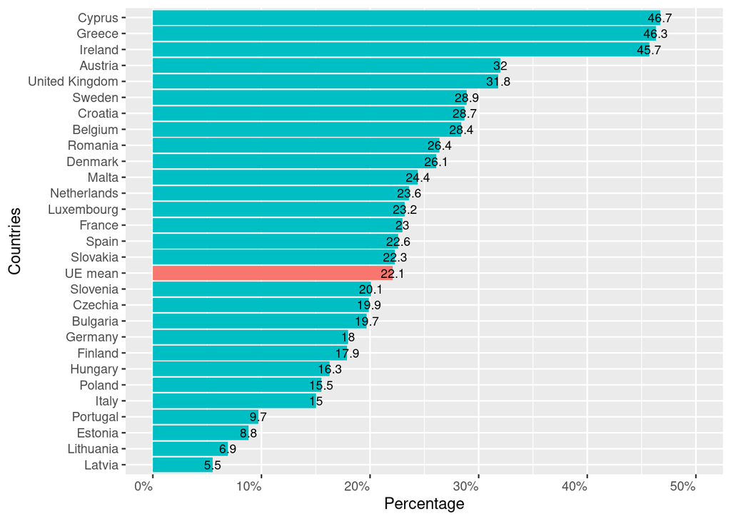

```r
#sph_total
ggplot(data = df_mean, aes(x = reorder(rownames(df_mean), sph_total), y = sph_total,
                      fill = ifelse(rownames(df_mean) == "UE mean", "Highlighted", "Normal"))) +
  coord_flip() +
  geom_bar(stat = "identity", position = "dodge") +
  xlab("Countries") +
  ylab("Percentage") +
  guides(fill = "none") +
  theme(axis.text.x = element_text(angle = 0, hjust = 1)) +
  geom_text(aes(label = sph_total), size = 3, position =    position_dodge(width = 0.9), vjust = 0.5) +
  scale_y_continuous(labels = function(x) paste0(x, "%"),
                     breaks=seq(0, 50, by = 10), limits=c(0, 50))
```

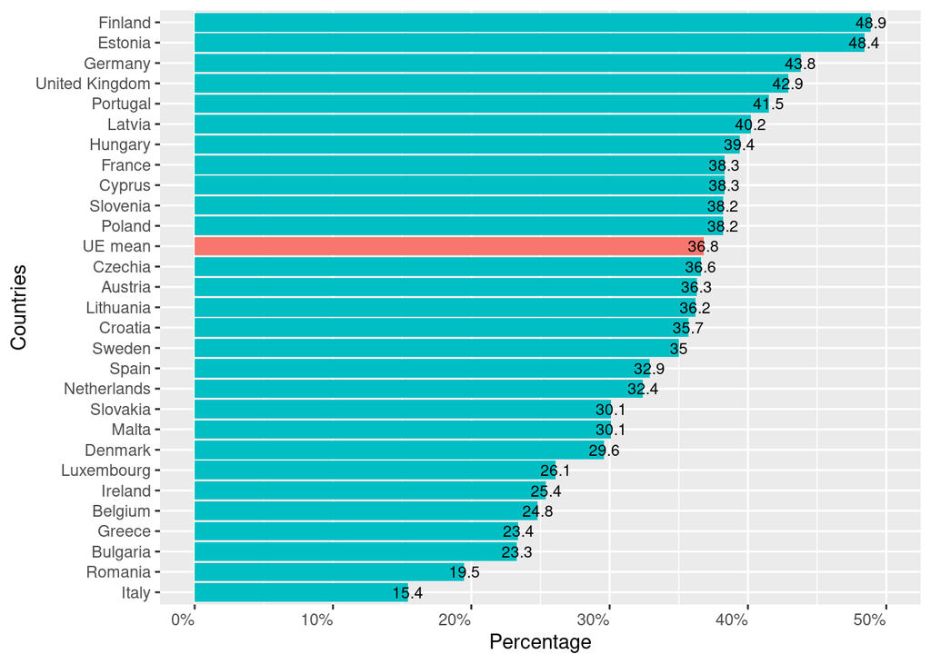

```r
#lng_stnd_illness
ggplot(data = df_mean, aes(x = reorder(rownames(df_mean), lng_stnd_illness), y = lng_stnd_illness,
                      fill = ifelse(rownames(df_mean) == "UE mean", "Highlighted", "Normal"))) +
  geom_bar(stat = "identity", position = "dodge") +
  coord_flip() +
  xlab("Countries") +
  ylab("Percentage") +
  guides(fill = "none") +
  theme(axis.text.x = element_text(angle = 0, hjust = 1)) +
  geom_text(aes(label = lng_stnd_illness), size = 3, position = position_dodge(width = 0.9), vjust = 0.5) +
    scale_y_continuous(labels = function(x) paste0(x, "%"),
                     breaks=seq(0, 50, by = 10), limits=c(0, 50))
```

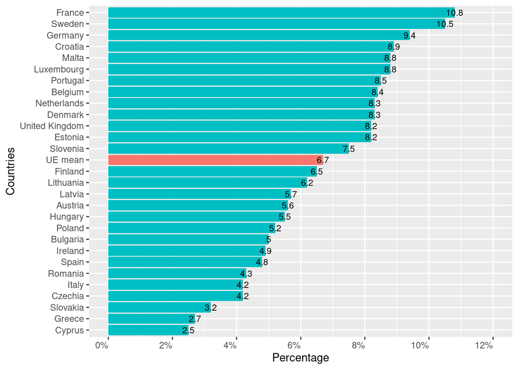

```r
#cds
ggplot(data = df_mean, aes(x = reorder(rownames(df_mean), cds), y = cds,
                      fill = ifelse(rownames(df_mean) == "UE mean", "Highlighted", "Normal"))) +
  geom_bar(stat = "identity", position = "dodge") +
  coord_flip() +
  xlab("Countries") +
  ylab("Percentage") +
  guides(fill = "none") +
  theme(axis.text.x = element_text(angle = 0, hjust = 1)) +
  geom_text(aes(label = cds), size = 3, position = position_dodge(width = 0.9), vjust = 0.5) +
      scale_y_continuous(labels = function(x) paste0(x, "%"),
                     breaks=seq(0, 12, by = 2), limits=c(0, 12))
```

# Standardization

```r
df.stand <- scale(df)
df.stand <- as.data.frame(df.stand)
glimpse(df.stand)
```

```
## Rows: 28
## Columns: 14
## $ hlty_total       <dbl> 0.30968927, 0.76707650, 0.17628466, -0.16675576, 0.76…
## $ hlte_sph_total   <dbl> 0.42166993, -1.16723127, -0.28722445, 0.47055920, 0.3…
## $ sph_total        <dbl> 0.47378735, -0.34013788, -0.32142696, 0.25861171, -0.…
## $ hbds_number      <dbl> -0.1919022, -0.2693283, -0.1492357, -0.5426512, 3.986…
## $ hlt_graduates    <dbl> 0.22570686, -0.50028496, -0.30113675, -0.42269042, 2.…
## $ hlt_per_exp_ncp  <dbl> -0.35487150, -0.42450688, -0.27366238, -0.48491730, 3…
## $ acc_at_work      <dbl> -0.2415769, -0.5159773, -0.3056164, -0.3441084, 3.733…
## $ cds              <dbl> 0.76309073, -0.68693397, -1.02811625, 0.72044294, 1.1…
## $ phy_number       <dbl> -0.20911272, -0.57050484, -0.46199743, -0.55716075, 2…
## $ cod              <dbl> -0.3218956, -0.3354437, -0.3115750, -0.5491334, 3.142…
## $ unm_needs        <dbl> 0.21601167, 0.27473329, -0.60609101, -0.48864777, -0.…
## $ hlt_care_exp     <dbl> -0.09319971, -0.55277098, -0.42803728, -0.27330006, 3…
## $ lng_stnd_illness <dbl> -1.0980897, -1.2778938, 0.3163697, -0.5227164, 1.1794…
## $ splong_lim       <dbl> -0.4987205, -1.1073706, 0.1447097, 0.6490198, -0.7421…
```

```r
sapply(df.stand, sd)
```

```
##       hlty_total   hlte_sph_total        sph_total      hbds_number
##                1                1                1                1
##    hlt_graduates  hlt_per_exp_ncp      acc_at_work              cds
##                1                1                1                1
##       phy_number              cod        unm_needs     hlt_care_exp
##                1                1                1                1
## lng_stnd_illness       splong_lim
##                1                1
```

```r
sapply(df.stand, mean)
```

```
##       hlty_total   hlte_sph_total        sph_total      hbds_number
##     3.375504e-16    -1.089023e-16     3.115145e-17     6.443646e-17
##    hlt_graduates  hlt_per_exp_ncp      acc_at_work              cds
##     9.668760e-18    -6.315478e-18    -4.313963e-17     3.395876e-17
##       phy_number              cod        unm_needs     hlt_care_exp
##     5.152671e-17     1.982541e-18     6.096701e-17     2.775558e-17
## lng_stnd_illness       splong_lim
##    -3.900340e-16    -1.744869e-16
```

# Boxplot of data after standardization

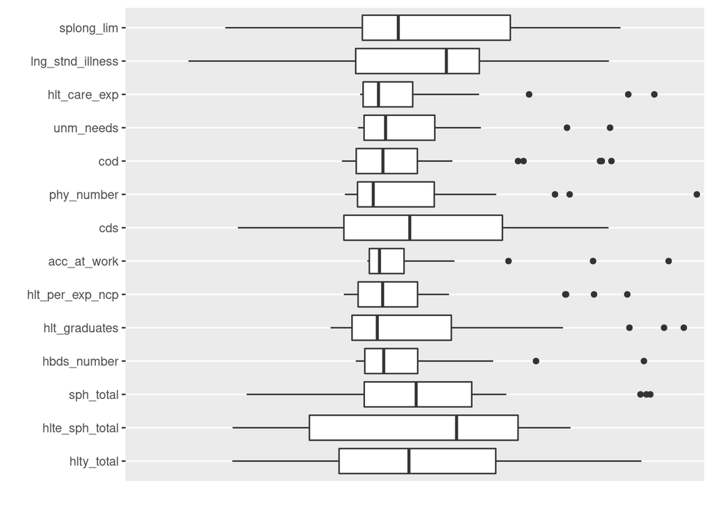

```r
ggplot(stack(df.stand), aes(x = ind, y = values)) +
  coord_flip() +
  scale_y_discrete() +
  ylab("") +
  xlab("") +
  geom_boxplot()
```

# K-means clustering:

## Visualisation of optimal number of clusters using wss method (Elbow method)

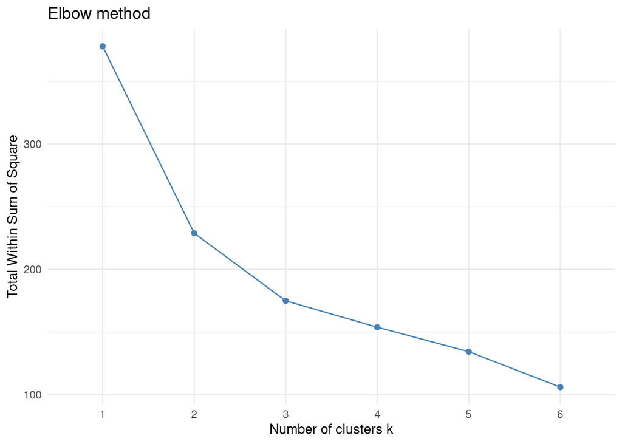

```r
fviz_nbclust(df.stand, kmeans, method = "wss", k.max = 6) + theme_minimal() + ggtitle("Elbow method")
```

## Visualisation of optimal number of cluster using GAP statistic

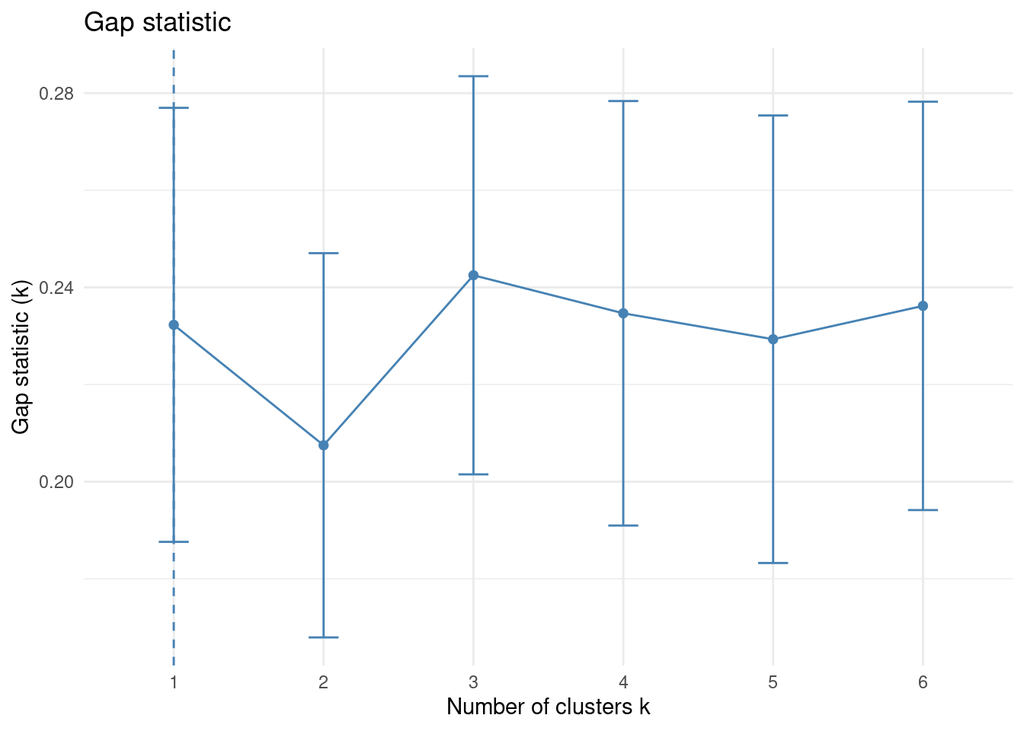

```r
gap_stat_1 <- clusGap(df.stand, FUN = kmeans, nstart = 1, K.max = 6, B = 150, d.power = 1)
fviz_gap_stat(gap_stat_1) + theme_minimal() + ggtitle("Gap statistic")
```

## K-means algorithm with 2 centers

```r
kme2 <- kmeans(df.stand, centers = 2, nstart = 20)
kme2$cluster
```

```
##        Belgium       Bulgaria        Czechia        Denmark        Germany
##              1              1              1              1              2
##        Estonia        Ireland         Greece          Spain         France
##              1              1              1              2              2
##        Croatia          Italy         Cyprus         Latvia      Lithuania
##              1              2              1              1              1
##     Luxembourg        Hungary          Malta    Netherlands        Austria
##              1              1              1              1              1
##         Poland       Portugal        Romania       Slovenia       Slovakia
##              1              1              1              1              1
##        Finland         Sweden United Kingdom
##              1              1              2
```

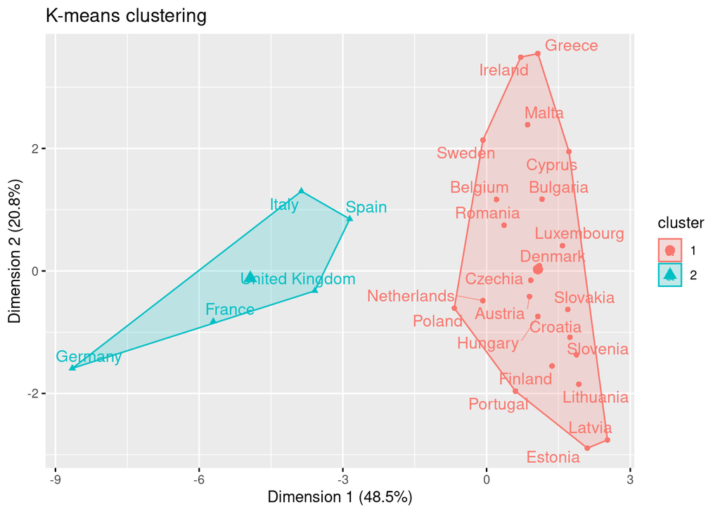

```r
fviz_cluster(kme2, df.stand, repel = T, main = "K-means clustering", xlab = "Dimension 1 (48.5%)", ylab = "Dimension 2 (20.8%)")
```

## K-means algorithm with 3 centers

```r
kme3 <- kmeans(df.stand, centers = 3, nstart = 20)
kme3$cluster
```

```
##        Belgium       Bulgaria        Czechia        Denmark        Germany
##              3              3              1              1              2
##        Estonia        Ireland         Greece          Spain         France
##              1              3              3              2              2
##        Croatia          Italy         Cyprus         Latvia      Lithuania
##              1              2              3              1              1
##     Luxembourg        Hungary          Malta    Netherlands        Austria
##              1              1              3              1              1
##         Poland       Portugal        Romania       Slovenia       Slovakia
##              1              1              3              1              1
##        Finland         Sweden United Kingdom
##              1              3              2
```

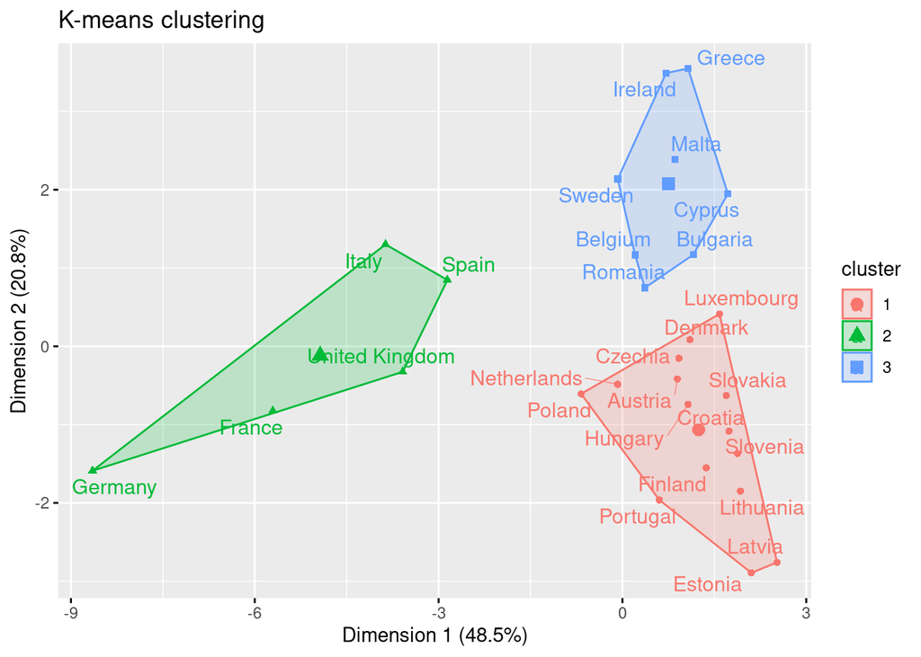

```r
fviz_cluster(kme3, df.stand, repel = T, main = "K-means clustering", xlab = "Dimension 1 (48.5%)", ylab = "Dimension 2 (20.8%)")
```

## Indexes tests

### Index S (Silhouette) test

```r
index.S(dist(df.stand), kme3$cluster) #centers = 3, score = 0.26
```

```
## [1] 0.2644859
```

```r
index.S(dist(df.stand), kme2$cluster) #centers = 2, score = 0.43 <- better
```

```
## [1] 0.4302728
```

### Index G1 test

```r
index.G1(df.stand, kme3$cluster) #centers = 3, wynik = 14.52
```

```
## [1] 14.52767
```

```r
index.G1(df.stand, kme2$cluster) #centers = 2, wynik = 16.9 <- better
```

```
## [1] 16.94969
```

### Index G2 test

```r
index.G2(dist(df.stand), kme3$cluster) #centers = 3, wynik = 0.757
```

```
## [1] 0.7569409
```

```r
index.G2(dist(df.stand), kme2$cluster)  #center = 3, wynik = 0.847 <- better
```

```
## [1] 0.8473797
```

### All indexes point to 2 clusters being optimal choice

# Linear ordering using Hellwig method :

## Weights vector :

**Area 1 (weight 2)** - Life expectancy and quality of life:

- hlty_total (healthy life),
- hlte_sph_total (healthy life expectancy),
- sph_total (self-perceived health),
- cds (current depressive symptoms),
- lng stnd illness (people having a long-standing illness or health problem),
- splong lim (self-perceived long-standing limitations in usual activities due to health problem).

**Area 2 (weight 1.5)** - characterising state of health service, medical care:

- hbds number (hospital beds),
- hlt graduates (health graduates),
- hlt per ex ncp (health personnel caregivers excluded),
- phy number (physicians by medical speciality),
- unm needs (self-reported unmet needs for medical examination),
- hlt care exp (health care expenditure).

**Area 3 (weight 1)** - contains additional, non medical indicators such as:

- acc at work (accidents at work),
- cod (causes of death).

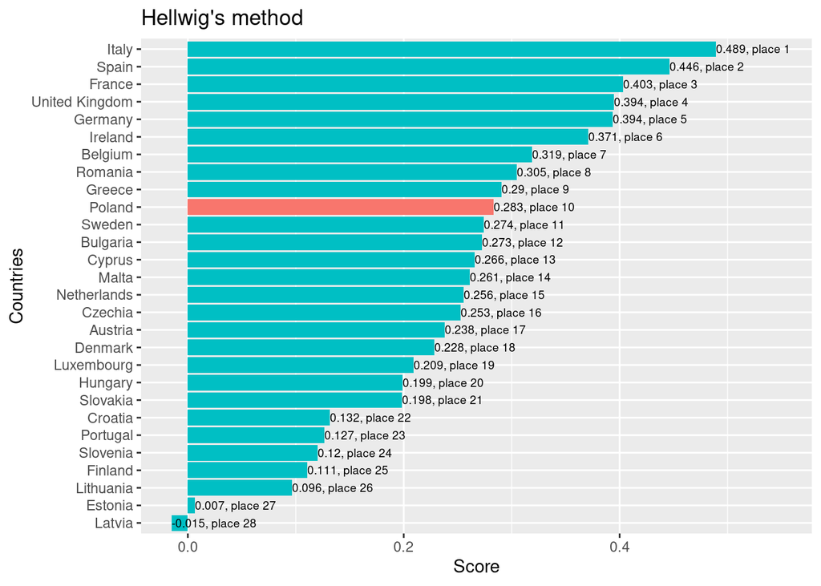

```r
weights. <- c(2, #hlty_total
          2, #hlte_sph_total
          2, #sph_total
          1.5, #hbds_number
          1.5, #hlt_graduates
          1.5, #hlt_per_exp_ncp
          1, #acc_at_work
          2, #cds
          1.5, #phy_number
          1, #cod
          1.5, #unm_needs
          1.5, #hlt_care_exp
          2, #lng_stnd_illness
          2  #splong_lim
          )

#Characters of variable
# + means stimulant,
# - means destimulant.
i <- c("+", "+", "+", "+", "+", "+", "-", "-", "+", "-", "-", "+", "-", "-")

x <- hellwig(df.stand, weights., i)
x <- x[order(x$rank),]

  ggplot(data = x, aes(y = score, x = reorder(rownames(x), score), fill = ifelse(rownames(x) == "Poland", "Highlighted", "Normal"))) +
  geom_bar(stat = "identity", position = "dodge") +
  coord_flip() +
  ylab("Score") +
  xlab("Countries") +
  ggtitle("Hellwig's method") +
  guides(fill = "none") +
  geom_text(aes(label =paste(round(score, 3), rank, sep = ", place ")), size = 2.5, position = position_dodge(width = 0.9), vjust = 0.5, hjust = 0) +
  ylim(-0.015, 0.55)
```

# Linear ordering using TOPSIS method :

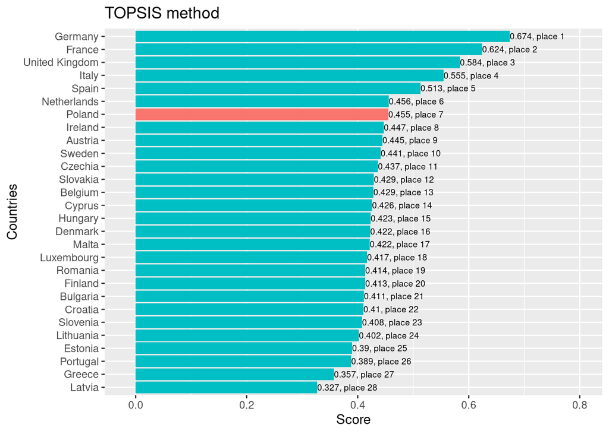

```r
nm <- topsis(as.matrix(df), weights., i)
df.topsis <- topsis(as.matrix(df), weights., i)
rownames(df.topsis) <- rownames(df)
df.topsis <- df.topsis[order(df.topsis$rank),]
nbnv <- df.topsis %>% dplyr::select(score, rank)

  ggplot(data = df.topsis, aes(y = score, x = reorder(rownames(df.topsis), score), fill = ifelse(rownames(df.topsis) == "Poland", "Highlighted", "Normal"))) +
  geom_bar(stat = "identity", position = "dodge") +
  coord_flip() +
  ylab("Score") +
  xlab("Countries") +
  ggtitle("TOPSIS method") +
  guides(fill = "none") +
  geom_text(aes(label =paste(round(score, 3), rank, sep = ", place ")), size = 2.5, position = position_dodge(width = 0.9), vjust = 0.5, hjust = 0) +
  ylim(-0.015, 0.8)
```

# Principal component analysis with two principal components

```r
DFPCA <- PCA(df.stand, scale.unit = FALSE, ncp = 2, graph = F)
```

## Eigenvalues

```r
DFPCA.eigval <- get_eigenvalue(DFPCA)
DFPCA.eigval
```

```
##         eigenvalue variance.percent cumulative.variance.percent
## Dim.1  6.546318234      48.49124618                    48.49125
## Dim.2  2.801928840      20.75502844                    69.24627
## Dim.3  1.590937557      11.78472265                    81.03100
## Dim.4  0.757045329       5.60774318                    86.63874
## Dim.5  0.563528092       4.17428216                    90.81302
## Dim.6  0.520205581       3.85337467                    94.66640
## Dim.7  0.311123897       2.30462146                    96.97102
## Dim.8  0.190744326       1.41292093                    98.38394
## Dim.9  0.094550308       0.70037265                    99.08431
## Dim.10 0.060831611       0.45060452                    99.53492
## Dim.11 0.034435176       0.25507538                    99.78999
## Dim.12 0.016848552       0.12480409                    99.91480
## Dim.13 0.009591563       0.07104862                    99.98584
## Dim.14 0.001910934       0.01415506                   100.00000
```

## Eigenvalues plot

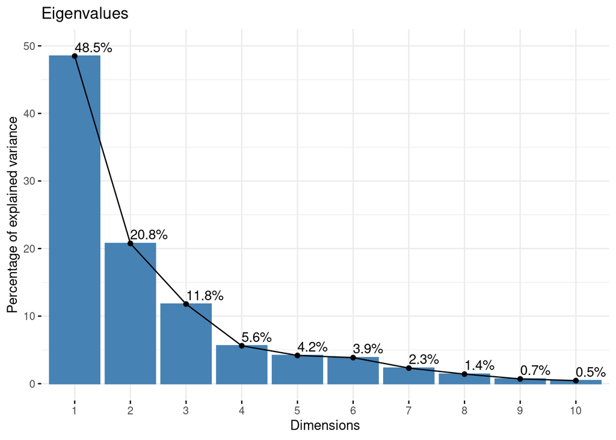

```r
fviz_eig(DFPCA, addlabels = TRUE, ylim = c(0, 50), main = "Eigenvalues", xlab = "Dimensions", ylab = "Percentage of explained variance")
```

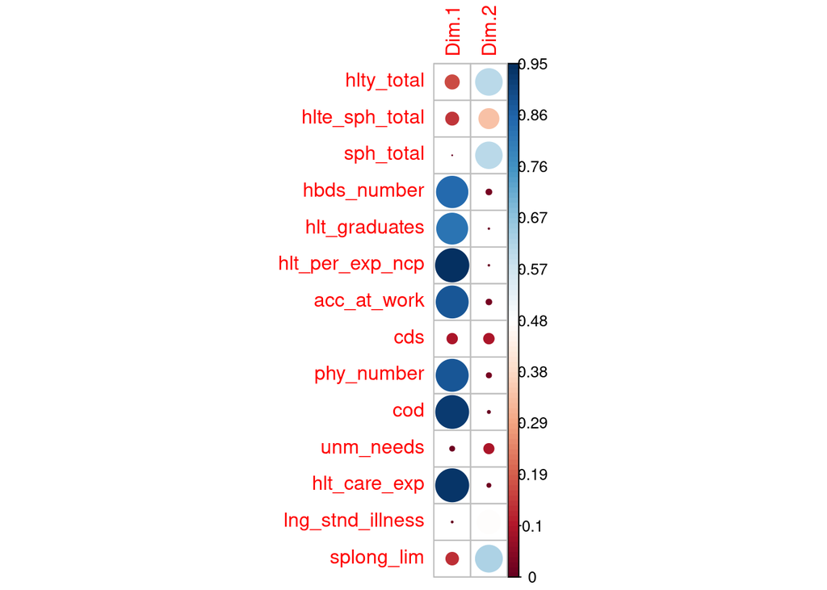

```r
var <- get_pca_var(DFPCA)
corrplot(var$cos2, is.corr=FALSE, col = COL2(, 100), number.cex= 7/ncol(df), cl.pos = 'r', cl.ratio = 1)
```

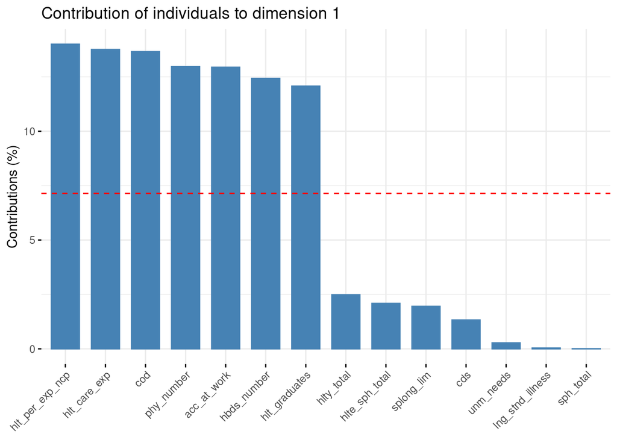

```r
fviz_contrib(DFPCA,
             choice = "var",
             axes = 1,
             top = 14,
             title = "Contribution of individuals to dimension 1")
```

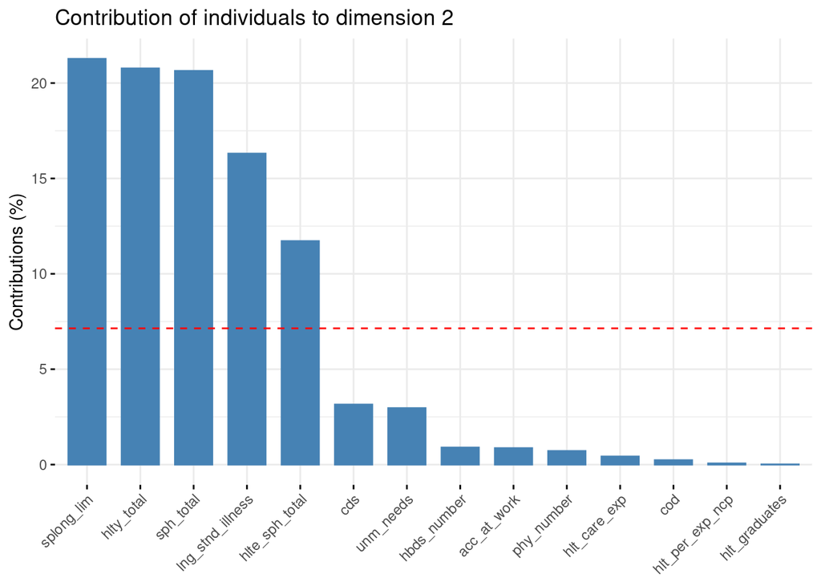

```r
fviz_contrib(DFPCA,
             choice = "var",
             axes = 2,
             top = 14,
             title = "Contribution of individuals to dimension 2")
```

```r
res.desc <- dimdesc(DFPCA, axes = c(1,2), proba = 0.05)
res.desc$Dim.1
```

```
## $quanti
##                 correlation      p.value
## hlt_per_exp_ncp   0.9748549 1.771684e-18
## hlt_care_exp      0.9664171 7.266877e-17
## cod               0.9628583 2.637972e-16
## phy_number        0.9381737 1.726896e-13
## acc_at_work       0.9372966 2.063530e-13
## hbds_number       0.9184882 5.606732e-12
## hlt_graduates     0.9053430 3.628674e-11
## hlty_total        0.4106522 2.995571e-02
## hlte_sph_total    0.3768420 4.807461e-02
##
## attr(,"class")
## [1] "condes" "list"
```

```r
res.desc$Dim.2
```

```
## $quanti
##                  correlation      p.value
## splong_lim         0.7861066 7.128811e-07
## lng_stnd_illness   0.6882189 5.167637e-05
## hlte_sph_total    -0.5834813 1.117328e-03
## sph_total         -0.7743869 1.326927e-06
## hlty_total        -0.7768193 1.169948e-06
##
## attr(,"class")
## [1] "condes" "list"
```

## Contribution of individuals to both dimensions

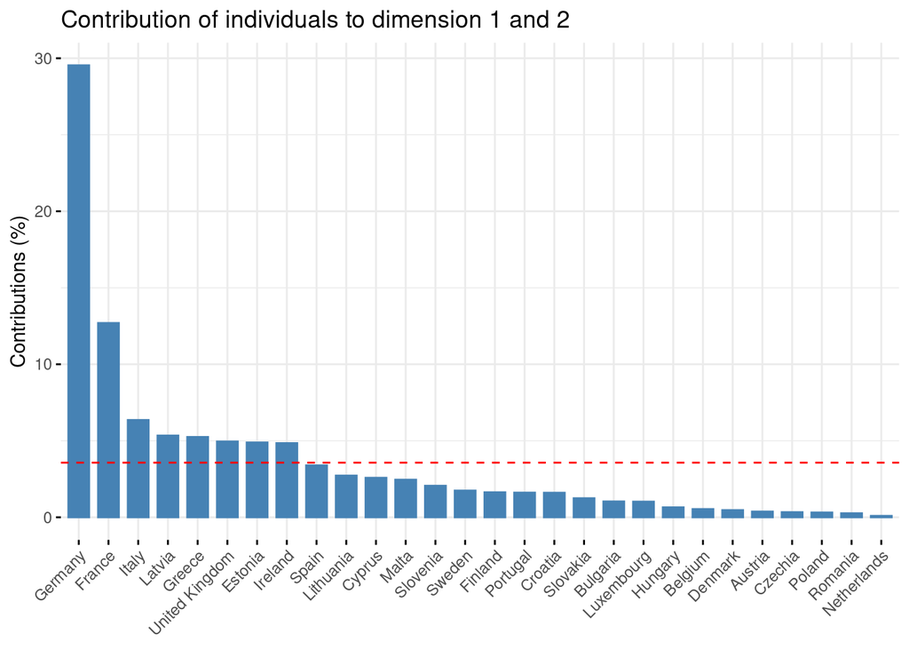

```r
fviz_contrib(DFPCA,
             choice = "ind",
             axes = 1:2,
             title = "Contribution of individuals to dimension 1 and 2")
```

## Biplot

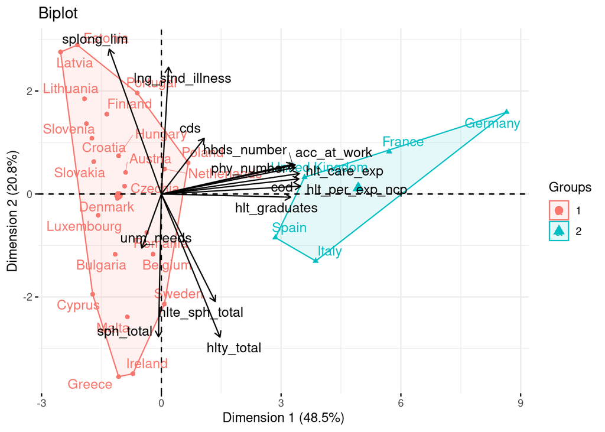

```r
fviz_pca_biplot(DFPCA,
                repel = TRUE,
                title = "Biplot",
                xlab="Dimension 1 (48.5%)",
                ylab="Dimension 2 (20.8%)",
                geom = c("point","text"),
                habillage = as.factor(kme2$cluster),
                col.var = "black", # Variables color
                col.ind = "#696969",  # Individuals color
                addEllipses = TRUE,
                ellipse.type = "convex"
                )
```

# Map of clustered countries

```
## 28 codes from your data successfully matched countries in the map
## 0 codes from your data failed to match with a country code in the map
## 215 codes from the map weren't represented in your data
```

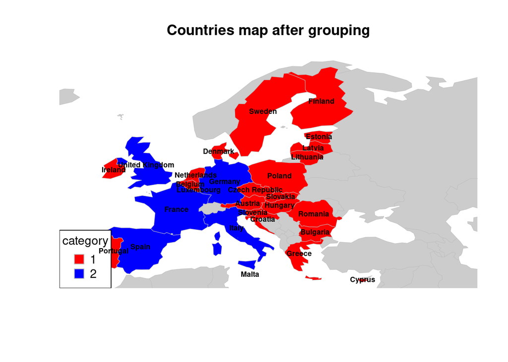